# PA1_template.Rmd

BK

Saturday, August 15, 2015

## Assignment 1, Reproducible Research

### Loading data and required libraries:

```r
library(dplyr)
library(lattice)
activity <- read.csv("activity.csv")
```

### Question 1: What is mean total number of steps taken per day?

*Finding the total number of steps/ day and plotting as a histogram*

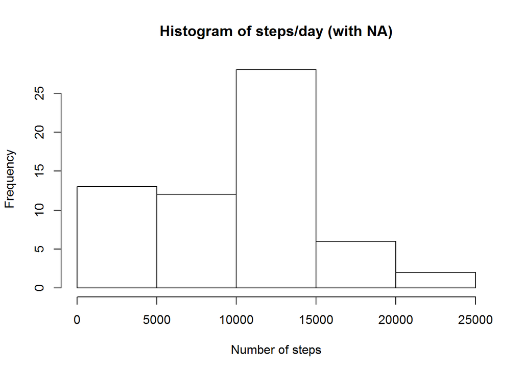

```r
#grouping activity by date and then finding the sum of number of steps/ day
daily <- group_by(activity, date)
dailySteps <- summarize (daily, steps = sum(steps, na.rm = TRUE))
#plotting and responding to the specific questions asked (histogram, mean and median)
hist(dailySteps$steps, xlab="Number of steps", main = "Histogram of steps/day (with NA)")
```

*Finding the mean and median number of steps/ day*

```r
mean(dailySteps$steps)
```

```
## [1] 9354.23
```

```r
median(dailySteps$steps)
```

```
## [1] 10395
```

### Question 2: What is the average daily activity pattern?

*Generating the time series plot of number of steps taken by time interval averaged across all days*

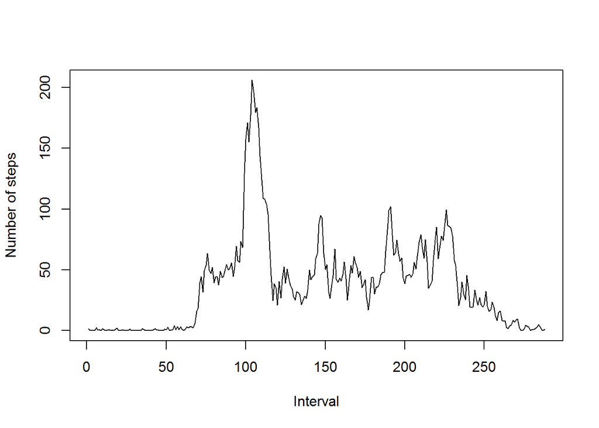

```r
#grouping activity by the 5 minute intervals each day is split into
fiveMin <- group_by(activity, interval)
#finding the average of number of steps/ interval (data within each interval is from
#the same time slot across multiple days)
fiveMinSteps <- summarize (fiveMin, steps = mean(steps, na.rm=TRUE))
#adding an ID to each interval. 288 intervals of 5 minutes each = 1,440 minutes = 24 hours/ day
fiveMinSteps$intervalID <- seq(1:288)
#plotting average number of steps against interval ID
with(fiveMinSteps, plot(steps~intervalID, type = "l", ylab = "Number of steps", xlab = "Interval"))
```

*Identifying the interval id which has the max number of steps, averaged across all days*

```r
#identifying the interval id which has the max number of steps, averaged across all days
maxAvg <- filter(fiveMinSteps, fiveMinSteps$steps == max(fiveMinSteps$steps))
maxAvg[[3]]
```

```
## [1] 104
```

### Question 3: Imputing missing values

*Total number of rows with NAs*

```r
#Part 1
#Total number of rows with NAs
table(complete.cases(activity))[[1]]
```

```
## [1] 2304
```

*Imputing interval mean values where there are NAs*

```r
#Part 2
#Step 1: Create a vector of mean steps/ interval and repeat it for each of the 61 days
#for which data has been captured.
#Step 2: Bind the new vector to the original activity data frame
#Step 3: Subset two separate data frames with and without NA
#Step 4: Impute interval mean values to NA

#Step1
meanSteps <- rep(fiveMinSteps$steps, 61)
#Step2
activity2 <- cbind(activity, meanSteps)
#Step3
activity3 <- subset(activity2, is.na(activity2$steps))
activity4 <- subset(activity2, !is.na(activity2$steps))
#Step4
activity3$steps <- activity3$meanSteps
```

*Creating a new dataset equal to the original dataset but with missing data filled in*

```r
#Part 3
#Merge the data frame originally with out NA and the one in which values are imputed
activity5 <- rbind(activity3, activity4)
```

*Plotting a histogram*

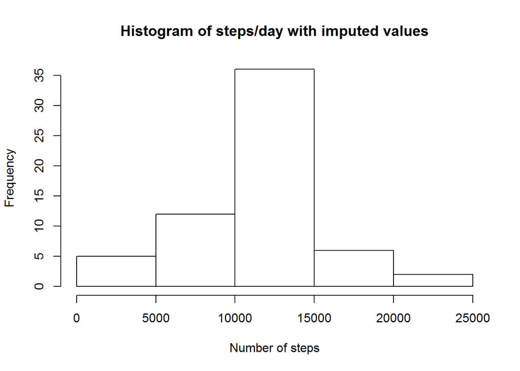

```r
#Part 4
#Group by date, sum steps by date, plot histogram and find mean & median
activity6 <- group_by(activity5, date)
activity7 <- summarize (activity6, steps = sum(steps))
hist(activity7$steps, xlab="Number of steps", main = "Histogram of steps/day with imputed values")
```

*Calculating the mean and median with imputed values. As seen, there is a significant difference between the raw data and imputing values. The Mean and Median are not only higher now, the Mean is also equal to the Median.*

```r
#Part 4
#Group by date, sum steps by date, plot histogram and find mean & median
mean(activity7$steps)
```

```
## [1] 10766.19
```

```r
median(activity7$steps)
```

```
## [1] 10766.19
```

### Question 4: Are there differences in activity patterns between weekdays and weekends?

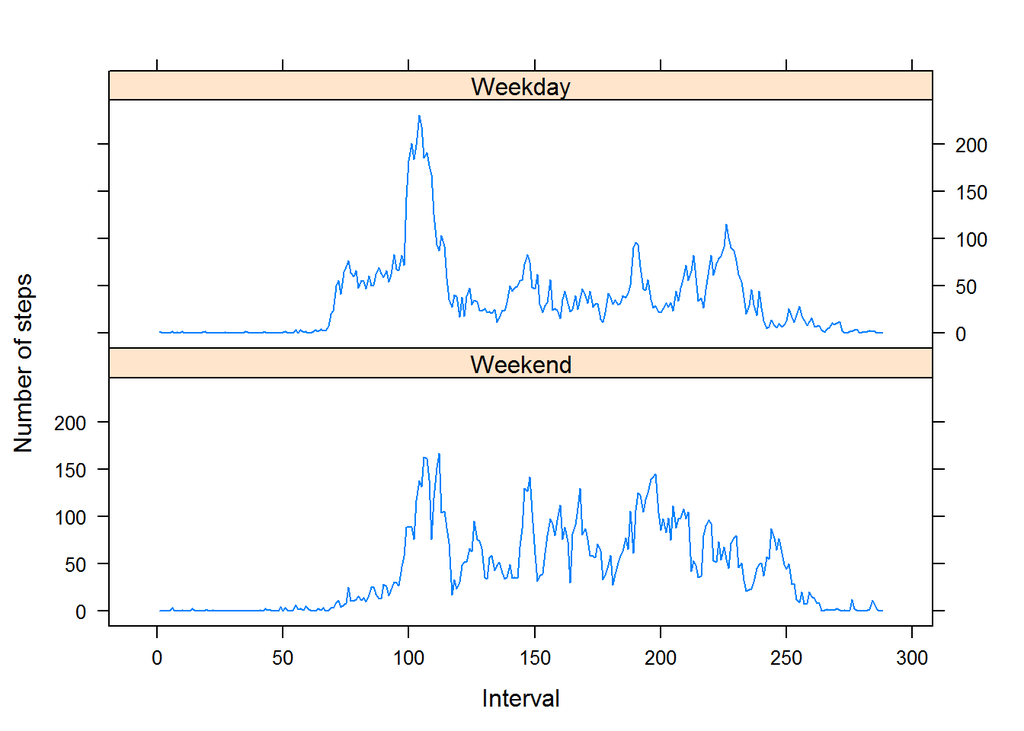

```r
#Step 1: Determine the day of the week and add this information as a new column
weekDay <- weekdays(as.Date(as.character(activity5$date)))
activity8 <- cbind(activity5, weekDay)
#Step 2: Subset weekend data, group by interval, calculate average steps/ interval across
#weekend days
activity9 <- subset(activity8, activity8$weekDay %in% c("Saturday", "Sunday"))
activity10 <- group_by(activity9, interval)
activity11 <- summarize (activity10, steps = mean(steps))
#Step 3: Add interval ID and a weekend flag as new columns
activity11$intervalID <- seq(1:288)
activity11$Day <- as.factor(rep("Weekend", 288))
#Step 4: Subset weekday data, group by interval, calculate average steps/ interval across
#weekdays
activity12 <- activity8[!(activity8$weekDay %in% c("Saturday", "Sunday")),]
activity13 <- group_by(activity12, interval)
activity14 <- summarize (activity13, steps = mean(steps))
#Step 5: Add interval ID and a weekday flag as new columns
activity14$intervalID <- seq(1:288)
activity14$Day <- as.factor(rep("Weekday", 288))
#Step 6: Combine the weekday and weekend data and plot it using the lattice plotting system
activity15 <- rbind(activity11, activity14)
xyplot(steps~intervalID | Day, data = activity15, layout =c(1,2), type = "l", ylab = "Number of steps", xlab = "Interval")
```